# Lab12: during lab activities

François Birgand

2023-03-30

For this lab, you are welcome to use all code source I have provided to you before and during lab as appropriate.

# Exercise 1

Plot the yearly hydrograph for the Cuyahoga River at Independence, Ohio. For this, copy/paste the correct code from a code cell from `BAE204-QClab.Rmd` and paste into a *code chunk* below. I have added a blank code chunk below you can use throughout. Make sure you adjust the x-axis label such that it reflects the years. Make sure you modify the title as well such that it reads *Flow rates at Cuyahoga River at Independence, OH*.

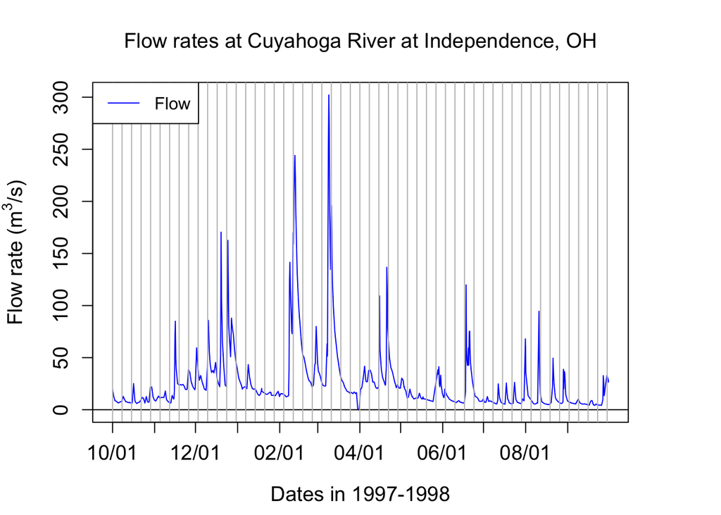

# Exercise 2

Calculate the lowest, highest, mean, median, as well as the $10^{th}$ and $90^{th}$ percentile of the flow rates. Make sure you use 3 significant digits. To report a number `N` with 4 significant digits, the syntax would be `signif(N,4)`.

In `R`, the code to calculate the mean of a vector `X` is `mean(X)`. To calculate the, e.g. 24% percentile of a variable X, the syntax is `quantile(X,0.24)`

The mean flow rate was 25.8 m<sup>3</sup>/s

# Exercise 3

Compare your values to the reference values for agricultural watersheds, which are, respectively, 5 mg N/L, 0.3 mg P/L, 0.03 mg P/L, and 20 mg TSS/L.

Report your results (in R Markdown) using this syntax and replace the `___` by embedded code

- The mean concentration for nitrate was ___ mg N/L
- The median concentration for nitrate was ___ mg N/L.

And so on. Compare mean versus median and discuss the difference. And there almost the same, or not. If they were really different, think about what would is say about the occurrence of high values. Compare them to the reference values we have seen in class. Similarly discuss your findings for the other parameters.

# Exercise 4

Plot the hydrograph and nitrate, TP, SRP, and TSS chemographs for the Cuyahoga River at Independence, Ohio, over the first two weeks of March 2009. You should make 4 plots for that. To ‘zoom in’ to these two weeks, in the code we used in lab and you probably pasted for exercise 1, the xlim are defined by ‘startdate’ and ‘enddate’. Modify them accordingly.

Using text, report whether the chemographs exhibit a concentration or a dilution effect.

# Exercise 5

Calculate the annual flow weighted average concentrations (FWAC) for nitrate, TP, SRP, and TSS, and compare them to the arithmetic average. Bonus +2: what higher/lower FWAC suggests on concentration/dilution effects.

# Exercise 6

Plot the flow volume duration curve over the entire period of record. Report the total flow volume that occurred in 2%, 5%, and 10% of the time, corresponding to the highest flow.

# Exercise 7

Plot the cumulative load duration curves for nitrate, phosphate, TP, and TSS over the entire period of record all on the same graph. Make sure you change colors. Report the total load that occurred in 2%, 5%, and 10% of the time, corresponding to the highest loads for each of the parameters .

Compare these values to the ones you obtained for flow, and discuss whether or not that makes sense.